# OLYMPICS T&F DATA FINAL REPORT

**Today, We will be looking at trends in Olympics data sets. Specifically, we will be examining Track and Field results guided by my research question: Are there any noticeable trends in performances of track and field athletes in specific events over the past century. To specify, how does factors like nationality and event type correlate to performance? This will primarily focus on the most successful countries.**

## **Introduction**

**My approach to this question is as follows: I am going to use multiple different visualizations and techniques to see how nationality affects the odds of placing in the Track and Fields games, and how does the nationality consider what event a competitor may be better at.**

## **ANALYSIS OF RESULTS DATA, EXAMINING MEDALS BY NATIONALITY.**

First, let’s start with loading our data sets.

```r
library(dplyr)
library(lubridate)
library(tidyr)
library(ggplot2)


results <- read.csv("C:\\Users\\adams\\Downloads\\184_FP_DATA\\results.csv")

extended_summer_results <- read.csv("C:\\Users\\adams\\Downloads\\184_FP_DATA\\summer.csv")

summer_results <- extended_summer_results %>%
  filter(Sport == "Athletics", Discipline == "Athletics")

country_data <- read.csv("C:\\Users\\adams\\Downloads\\184_FP_DATA\\olympic-medals-by-country-2023.csv")


FirstTen<- head(country_data,10)
LastTen <- tail(country_data,10)
FirstTen
```

|  | country | olympicMedalsByCountry_totAll | olympicMedalsByCountry_totGold | olympicMedalsByCountry_totSilv | olympicMedalsByCountry_totBrz |
| --- | --- | --- | --- | --- | --- |
| 1 | United States | 2980 | 1180 | 959 | 841 |
| 2 | United Kingdom | 948 | 296 | 320 | 332 |
| 3 | Germany | 892 | 293 | 293 | 306 |
| 4 | France | 874 | 258 | 289 | 327 |
| 5 | Italy | 742 | 257 | 224 | 261 |
| 6 | China | 696 | 275 | 227 | 194 |
| 7 | Sweden | 661 | 205 | 222 | 234 |
| 8 | Australia | 562 | 169 | 178 | 215 |
| 9 | Japan | 555 | 183 | 172 | 200 |
| 10 | Russia | 547 | 196 | 164 | 187 |

```r
LastTen
```

|  | country | olympicMedalsByCountry_totAll | olympicMedalsByCountry_totGold | olympicMedalsByCountry_totSilv | olympicMedalsByCountry_totBrz |
| --- | --- | --- | --- | --- | --- |
| 126 | Eritrea | 1 | 0 | 0 | 1 |
| 127 | Gabon | 1 | 0 | 1 | 0 |
| 128 | Mauritius | 1 | 0 | 0 | 1 |
| 129 | Cyprus | 1 | 0 | 1 | 0 |
| 130 | Djibouti | 1 | 0 | 0 | 1 |
| 131 | Guyana | 1 | 0 | 0 | 1 |
| 132 | Montenegro | 1 | 0 | 1 | 0 |
| 133 | Barbados | 1 | 0 | 0 | 1 |
| 134 | Samoa | 1 | 0 | 1 | 0 |
| 135 | Tonga | 1 | 0 | 1 | 0 |

```r
glimpse(results)
```

```
Rows: 2,406
Columns: 8
$ Gender      <chr> "M", "M", "M", "M", "M", "M…
$ Event       <chr> "10000M Men", "10000M Men",…
$ Location    <chr> "Rio", "Rio", "Rio", "Beiji…
$ Year        <int> 2016, 2016, 2016, 2008, 200…
$ Medal       <chr> "G", "S", "B", "G", "S", "B…
$ Name        <chr> "Mohamed FARAH", "Paul Kipn…
$ Nationality <chr> "USA", "KEN", "ETH", "ETH",…
$ Result      <chr> "25:05.17", "27:05.64", "27…
```

```r
nrow(summer_results)
```

```
[1] 3638
```

Let’s dive into nationality first. At this point its almost common knowledge that the US is a dominant force in Track and Field, but lets confirm this information.

To start we have a simple query. The USA, Great Britian, and Soviet Union lead in medal counts.

```r
results1 <- results %>%
  group_by(Medal, Nationality) %>%
  summarise(total = n()) %>%
  arrange(desc(total))
results1 <- results1 %>% filter(Medal != "")

results1 <- results1 %>%
  pivot_wider(names_from = Medal, values_from = total, values_fill = 0)

results1
```

| Nationality | G | S | B |
| --- | --- | --- | --- |
| USA | 275 | 206 | 158 |
| GBR | 46 | 58 | 56 |
| URS | 44 | 39 | 48 |
| GER | 16 | 22 | 36 |
| KEN | 26 | 36 | 25 |
| JAM | 22 | 32 | 20 |
| FIN | 31 | 22 | 21 |
| GDR | 29 | 24 | 23 |
| SWE | 12 | 13 | 28 |
| CAN | 11 | 15 | 27 |

[output cut: 87 more lines]

As we can see, the USA is far ahead of the next view countries, indicating the USA is a dominate force in Track and Field, but lets do some more statistics to confirm this hypothesis.

```r
#Rename United States to USA to match cases


top_countries <- c("USA", "GBR", "URS", "GER", "KEN", "JAM", "FIN", "SWE", "CAN", "FRA")

calculate_percentage <- function(country, results1, country_data) {
  percentage <- results1 %>%
    group_by(Nationality) %>%
    filter(Nationality == country ) %>%
    summarise(Percentage = (G / sum(country_data$olympicMedalsByCountry_totGold))* 100)
  return(percentage)
}

percentage_list <- lapply(top_countries, calculate_percentage, results1 = results1, country_data = country_data)


combined_percentages <- bind_rows(percentage_list)


combined_percentages
```

| Nationality | Percentage |
| --- | --- |
| USA | 4.9221407 |
| GBR | 0.8233399 |
| URS | 0.7875425 |
| GER | 0.2863791 |
| KEN | 0.4653660 |
| JAM | 0.3937713 |
| FIN | 0.5548595 |
| SWE | 0.2147843 |
| CAN | 0.1968856 |
| FRA | 0.2147843 |

```r
NA
NA
```

Let’s visualize how successful the two most successful countries are in Track and Field.

```r
Filtered_USA_Bar <- results %>%
  select(Medal,Nationality)

Filtered_USA_Bar <- Filtered_USA_Bar %>%
  mutate(
    Medal = ifelse(is.na(Medal), "Unknown", Medal),
    Nationality = ifelse(is.na(Nationality), "Unknown", Nationality)
  )

Filtered_USA_Bar <- Filtered_USA_Bar %>%
  group_by(Medal,Nationality) %>%
  summarise(count = n())
Filtered_USA_Bar <- Filtered_USA_Bar[-1,]

Filtered_USA_Bar <- Filtered_USA_Bar %>%
  pivot_wider(names_from = Medal, values_from = count, values_fill = 0)
```

Here’s a visualization to see how many more Track and Field medals USA has compared to the second place in Track and Field.

[figure not shown]

```r
BarGraph_Ready <- Filtered_USA_Bar %>%
  filter(Nationality %in% c("USA", "GBR"))

ggplot(BarGraph_Ready, aes(x = Nationality)) +
  geom_bar(aes(y = G, fill = "Bronze"), stat = "identity", position = "dodge") +
  geom_bar(aes(y = S, fill = "Silver"), stat = "identity", position = "dodge") +
  geom_bar(aes(y = B, fill = "Gold"), stat = "identity", position = "dodge") + labs(title = "Medal Counts by Nationality",
       x = "Nationality",
       y = "Count",
       fill = "Medal Type") +
  scale_fill_manual(values = c("Bronze" = "peru", "Silver" = "gray", "Gold" = "gold")) +
  theme_minimal()
```

## **ANALYSIS WRANGLING VISUALIZATION OF SUMMER RESULTS. EXAMMINING EVENT PLACEMENTS NATIONALITY**

Now let’s add another layer of complexion. Events in Track and Field have an array of competitors. Some are extremely limber and built for distance. Others are powerful, strong competitors built for speed. Let’s see if Nationality correlates to how a competitor may do in a specific event and not just overall medals.

Specifically, lets start with nationality in the longest two events(10k meter and 5k meter) VS. the two shortest event(100m and 110H meter)

```r
Short_Long_Events <- c("10000M", "5000M", "110M Hurdles", "100M")

Short_Long_Filtered <- summer_results %>%
  filter(Event %in% Short_Long_Events)

group_Short_Long <- Short_Long_Filtered %>%
  group_by(Country, Event,Medal) %>%
  summarise(total = n()) %>%
  arrange(desc(total))
group_Short_Long <- group_Short_Long %>%
  pivot_wider(names_from = Medal, values_from = total, values_fill = 0)
```

For the sake of convinence and removing less impactful countries, lets remove all countries with not in the top 3 for the four events before plotting.

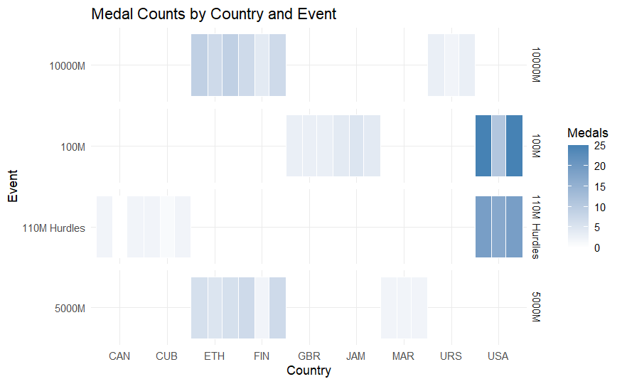

```r
#getting top 3 best countries for visual sake
Most_Medals <- group_Short_Long %>%
  group_by(Event) %>%
  top_n(3, Gold) %>%
  ungroup()

ggplot(Most_Medals,aes(x = Country, y = Event)) +
  geom_tile(aes(fill = Gold), color = "white") + #Gold
  geom_tile(aes(fill = Silver), color = "white", width = 0.3) +  # Silver
  geom_tile(aes(fill = Bronze), color = "white", width = -0.3) + # Bronze
  facet_grid(Event ~ ., scales = "free_y") +
  labs(title = "Medal Counts by Country and Event",
       x = "Country",
       y = "Event",
       fill = "Medals") +
  theme_minimal() +
  scale_fill_gradient(low = "white", high = "steelblue")
```

This supports are analysis of the previous graph that led to the conclusion the USA is more likely to breed Track and Field medalist. However, to really confirm this takeaway lets look at throwing events too. More events in the favor of the USA would be enough evidence to conclude that Nationality is a massive predictor of Track and Field performance.

```r
Throw_Events <- c("Hammer Throw", "Javelin Throw","Discus Throw","Shot Put")

Throw_Events <- summer_results %>%
  filter(Event %in% Throw_Events)

Grouped_Throw <- Throw_Events %>%
  group_by(Country, Event,Medal) %>%
  summarise(total = n()) %>%
  arrange(desc(total))
Grouped_Throw_Wider <- Grouped_Throw %>%
  pivot_wider(names_from = Medal, values_from = total, values_fill = 0)
```

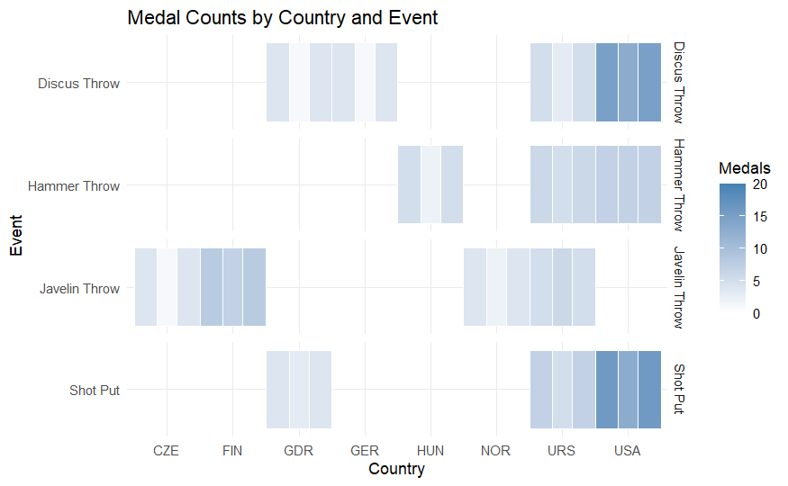

```r
#getting top 3 best countries for visual sake
Most_Medals2 <- Grouped_Throw_Wider %>%
  group_by(Event) %>%
  top_n(3, Gold) %>%
  ungroup()

ggplot(Most_Medals2,aes(x = Country, y = Event)) +
  geom_tile(aes(fill = Gold), color = "white") + #Gold
  geom_tile(aes(fill = Silver), color = "white", width = 0.3) +  # Silver
  geom_tile(aes(fill = Bronze), color = "white", width = -0.3) + # Bronze
  facet_grid(Event ~ ., scales = "free_y") +
  labs(title = "Medal Counts by Country and Event",
       x = "Country",
       y = "Event",
       fill = "Medals") +
  theme_minimal() +
  scale_fill_gradient(low = "white", high = "steelblue")
```

To confirm all hypothesis and suspicions we have about nationality being a leading predictor in event performance, lets do some more analysis. Here I hope to visualize all competitors from a certain country and their results in the jumping events. We have examined short and long events, throws, the only thing missing is the jump events. Let’s wrangle the data before making a bubble plot to compare these.

There is two types of jumps, vertical and horizontal jumps. Let’s visualize verticals first. I would expect the USA and USSR to be more successful in these events. They statistically have been seen more in the more explosive events. Countries like Ethiopia and Finland should not be on here. They tend to focus more on longer events.

```r
VerticalJumps <- c("High Jump Men", "Pole Vault Men")
results2 <- results %>%
  filter(Event %in% VerticalJumps)

results2$Result <- as.numeric(results2$Result)

results2 <- results2 %>%
  pivot_wider(names_from = Event, values_from = Result, values_fill = 0)

results2 <- results2 %>%
  rename(HighJump = "High Jump Men")

results2 <- results2 %>%
  rename(PoleVault = "Pole Vault Men")

athlete_count <- results2 %>%
  group_by(Nationality) %>%
  summarise(AthleteCount = n())

results2 <- left_join(results2, athlete_count, by = "Nationality")

Polevault <- results2 %>%
  filter(PoleVault != 0)
Polevault <- Polevault %>% select(-HighJump)

Highjump <- results2 %>%
  filter(HighJump != 0)
Highjump <- Highjump %>% select(-PoleVault)
```

Now Visualize the Results with Color Codes by Country and size by Athlete Number. I’m adding in a smooth_line over the points to see how they have progressed over the years. If it flattens out, that will tell us countries have peaked in their performance metrics.

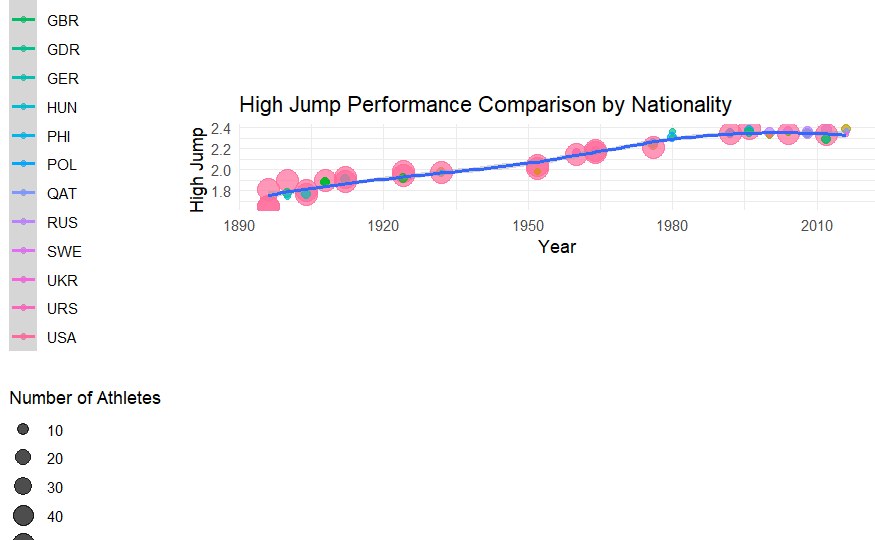

```r
ggplot(Highjump,aes(x = Year, y = HighJump, color = Nationality), ) +
  geom_point(aes(size = AthleteCount),alpha = 0.7) + geom_smooth(aes(group = 1)) +
  labs(title = "High Jump Performance Comparison by Nationality",
       x = "Year",
       y = "High Jump ",
       color = "Nationality",
       size = "Number of Athletes") +
  theme_minimal() +
  theme(plot.margin = margin(2,0,6,0,"cm"), legend.position = "left")
```

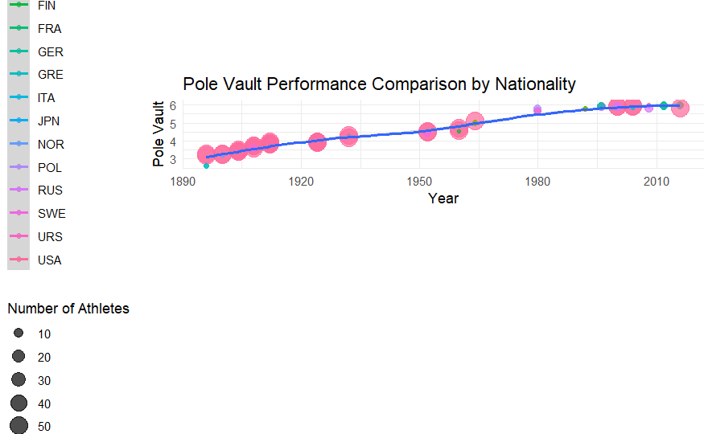

```r
ggplot(Polevault,aes(x = Year, y = PoleVault, color = Nationality), ) +
  geom_point(aes(size = AthleteCount),alpha = 0.7) + geom_smooth(aes(group = 1)) +
  labs(title = "Pole Vault Performance Comparison by Nationality",
       x = "Year",
       y = "Pole Vault",
       color = "Nationality",
       size = "Number of Athletes") +
  theme_minimal() +
  theme(plot.margin = margin(2,0,6,0,"cm"), legend.position = "left")
```

```r
NA
NA
NA
```

Looking at the vertical jump results, We can see a distinct size of the bubble depending on the country they are from. An important thing to keep in mind with this data is that results only consider those who medaled, so having a larger bubble size indicates a more successful country. Over the years of the Olympic games, all countries improved their vertical jump marks, but one country seems to stand out the most. Again, the USA consistently had the most amount of medalist and some top performances over the decades. Further indicating Nationality has a large role in the performance of an event. The USSR has also had success in this area. This supports the earlier prediction that some countries focus on powerful, more explosive events.

Is the same true for the horizontal jump?

```r
HorizontalJumps <- c("Long Jump Men", "Triple Jump Men")
results2 <- results %>%
  filter(Event %in% HorizontalJumps)

results2$Result <- as.numeric(results2$Result)

results2 <- results2 %>%
  pivot_wider(names_from = Event, values_from = Result, values_fill = 0)

results2 <- results2 %>%
  rename(LongJump = "Long Jump Men")

results2 <- results2 %>%
  rename(TripleJump = "Triple Jump Men")

athlete_count <- results2 %>%
  group_by(Nationality) %>%
  summarise(AthleteCount = n())

results2 <- left_join(results2, athlete_count, by = "Nationality")

Longjump <- results2 %>%
  filter(LongJump != 0)
Longjump <- Longjump %>% select(-TripleJump)

Triplejump <- results2 %>%
  filter(TripleJump != 0)
Triplejump <- Triplejump %>% select(-LongJump)
```

Visualize same as vertical jumps

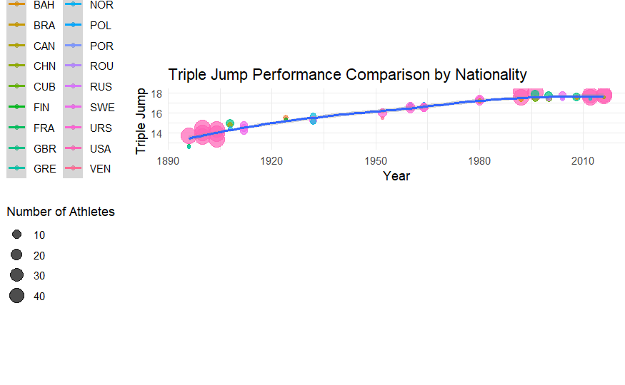

```r
ggplot(Triplejump,aes(x = Year, y = TripleJump, color = Nationality), ) +
  geom_point(aes(size = AthleteCount),alpha = 0.7) + geom_smooth(aes(group = 1)) +
  labs(title = "Triple Jump Performance Comparison by Nationality",
       x = "Year",
       y = "Triple Jump ",
       color = "Nationality",
       size = "Number of Athletes") +
  theme_minimal() +
  theme(plot.margin = margin(2,0,6,0,"cm"), legend.position = "left")
```

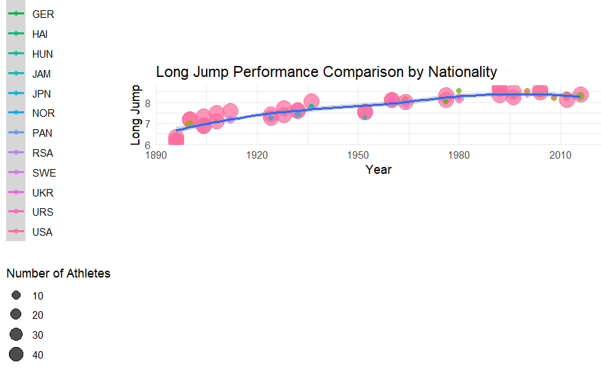

```r
ggplot(Longjump,aes(x = Year, y = LongJump, color = Nationality), ) +
  geom_point(aes(size = AthleteCount),alpha = 0.7) + geom_smooth(aes(group = 1)) +
  labs(title = "Long Jump Performance Comparison by Nationality",
       x = "Year",
       y = "Long Jump",
       color = "Nationality",
       size = "Number of Athletes") +
  theme_minimal() +
  theme(plot.margin = margin(2,0,6,0,"cm"), legend.position = "left")
```

Interestingly, we don’t see the exact same trends as noted before, but they are similar. Although most events have gone up over the years, long jump has actually began to slow down in progress. This indicates most countries have peaked in their performance metrics for long jump. Also noteworthy, the USA does not dominate Triple Jump nearly as much as other events which is odd for an event that focuses on power. However, they do still hold the majority of medalist as indicated by the bubble size in both the Triple and Long Jump. Further supporting the conclusion that nationality indicates success in certain events.

## **CONCLUSION**

**The initial thoughts about countries predicting success and countries predicting success in event types is likely true. All statistics and visualizations pointed towards certain countries being overall more successful in Track and Field. For event type success relating to countries, Multiple visualizations of events including jumps, throws, long, and short distance all indicate certain countries have excelled.**

**The most compelling fact though was that certain countries are much more likely to medal. All the visualization and queries indicate the USA is the most dominant force in Track and Field. This is likely from a specialization in this sport. Other hypothesis such as Jamaica focusing on sprints and Ethiopia focusing on distance are also likely true. History shows those countries have had top performers in both events, so it is likely nationality or country of origin is a good indicator of the performance and success in a Track and Field Event.**